# **Used Cars Price Prediction** ( India )

## **Problem Definition**

### **The Context:**

- Why is this problem important to solve?

The used car market is vast, with millions of transactions happening every year. However, it remains highly fragmented, with inconsistent pricing practices that can lead to customer distrust, reduced profitability for dealerships, and inefficient pricing strategies. Traditional methods for valuing used cars often rely on subjective judgment, static price books, or generalized estimation tools that may not reflect the specific characteristics and condition of each vehicle.

In this context, data-driven pricing emerges as a critical solution for dealerships looking to build trust and ensure competitiveness. With recent advancements in machine learning and data availability, predictive modeling can provide dealerships with an effective way to determine fair market prices for used vehicles. These models analyze a range of factors, including car make, model, year, mileage, engine specifications, fuel type, location, and real-time market trends, to deliver accurate and transparent pricing.

This project leverages machine learning algorithms to develop a predictive pricing tool for used cars. By analyzing historical data and key vehicle attributes, this tool enables dealerships to set prices based on data-driven insights, increasing the transparency and consistency of their pricing strategies. The solution not only helps dealerships make more informed pricing decisions but also enhances customer trust, aligning dealership pricing practices with market demands and reducing the likelihood of over- or under-pricing vehicles.

In an industry where customers are increasingly aware of and sensitive to price fairness, implementing a predictive pricing tool offers dealerships a significant advantage. This tool provides a scalable, flexible approach that can adapt to market changes, making it a vital asset for dealerships aiming to optimize profitability while offering customers transparent and fair vehicle prices.

### **The objective:**

- What is the intended goal?

The goal is to build a predictive model that estimates the selling price of a used car based on various features such as age, kilometers driven, fuel type, transmission, and more. This will help potential sellers and buyers make informed decisions regarding the fair market value of a car.

### **The key questions:**

- What are the key questions that need to be answered?

1- What are the key factors that most influence the price of a used car?

2- How do features like fuel type, transmission, and kilometers driven affect the resale value?

3- Can we build an accurate model to predict the price of a used car based on the given features?

### **The problem formulation**:

- What is it that we are trying to solve using data science?

We are trying to predict the price of used cars using data science techniques. By analyzing historical data of cars with various features, we aim to develop a model that can accurately estimate a car's price based on its characteristics (age, mileage, engine size, etc.).

### **Data Dictionary**

**S.No.** : Serial Number

**Name** : Name of the car which includes Brand name and Model name

**Location** : The location in which the car is being sold or is available for purchase (Cities)

**Year** : Manufacturing year of the car

**Kilometers_driven** : The total kilometers driven in the car by the previous owner(s) in KM

**Fuel_Type** : The type of fuel used by the car (Petrol, Diesel, Electric, CNG, LPG)

**Transmission** : The type of transmission used by the car (Automatic / Manual)

**Owner** : Type of ownership

**Mileage** : The standard mileage offered by the car company in kmpl or km/kg

**Engine** : The displacement volume of the engine in CC

**Power** : The maximum power of the engine in bhp

**Seats** : The number of seats in the car

**New_Price** : The price of a new car of the same model in INR 100,000

**Price** : The price of the used car in INR 100,000 (**Target Variable**)

### **Loading libraries**

```python
# Data manipulation and analysis
import pandas as pd
import numpy as np

# Visualization libraries
import matplotlib.pyplot as plt
import seaborn as sns

# Machine Learning libraries
from sklearn.model_selection import train_test_split,GridSearchCV
from sklearn.model_selection import RandomizedSearchCV
from sklearn.linear_model import LinearRegression
from sklearn.impute import KNNImputer
from sklearn.ensemble import RandomForestRegressor
from sklearn.metrics import mean_squared_error, r2_score
from sklearn.linear_model import Ridge, Lasso
from sklearn.tree import DecisionTreeRegressor
from sklearn.neighbors import KNeighborsRegressor
from sklearn.inspection import permutation_importance

# For data preprocessing
from sklearn.preprocessing import StandardScaler, LabelEncoder
```

### **Let us load the data**

```python
# Load the dataset
file_path = 'used_cars.csv'  # Replace this with the correct path to your file
used_cars_data = pd.read_csv(file_path)

# Display the first few rows of the dataset to verify it's loaded correctly
used_cars_data.head()
```

|  | S.No. | Name | Location | Year | Kilometers_Driven | Fuel_Type | Transmission | Owner_Type | Mileage | Engine | Power | Seats | New_price | Price |
| --- | --- | --- | --- | --- | --- | --- | --- | --- | --- | --- | --- | --- | --- | --- |
| 0 | 0 | Maruti Wagon R LXI CNG | Mumbai | 2010 | 72000 | CNG | Manual | First | 26.60 | 998.0 | 58.16 | 5.0 | NaN | 1.75 |
| 1 | 1 | Hyundai Creta 1.6 CRDi SX Option | Pune | 2015 | 41000 | Diesel | Manual | First | 19.67 | 1582.0 | 126.20 | 5.0 | NaN | 12.50 |
| 2 | 2 | Honda Jazz V | Chennai | 2011 | 46000 | Petrol | Manual | First | 18.20 | 1199.0 | 88.70 | 5.0 | 8.61 | 4.50 |
| 3 | 3 | Maruti Ertiga VDI | Chennai | 2012 | 87000 | Diesel | Manual | First | 20.77 | 1248.0 | 88.76 | 7.0 | NaN | 6.00 |
| 4 | 4 | Audi A4 New 2.0 TDI Multitronic | Coimbatore | 2013 | 40670 | Diesel | Automatic | Second | 15.20 | 1968.0 | 140.80 | 5.0 | NaN | 17.74 |

## Data Overview

- Observations
- Sanity checks
1. **Basic Overview**

   Start by understanding the structure of the dataset:
   - `.info()`: This will give us an overview of the data types and check if there are any missing values.
   - `.describe()`: This will show the summary statistics (mean, standard deviation, min, max, etc.) for the numerical columns.

```python
# Check the basic structure and summary statistics of the dataset
print(used_cars_data.info())
print(used_cars_data.describe())
```

```
<class 'pandas.core.frame.DataFrame'>
RangeIndex: 7253 entries, 0 to 7252
Data columns (total 14 columns):
 #   Column             Non-Null Count  Dtype
---  ------             --------------  -----
 0   S.No.              7253 non-null   int64
 1   Name               7253 non-null   object
 2   Location           7253 non-null   object
 3   Year               7253 non-null   int64
 4   Kilometers_Driven  7253 non-null   int64
 5   Fuel_Type          7253 non-null   object
 6   Transmission       7253 non-null   object
 7   Owner_Type         7253 non-null   object
 8   Mileage            7251 non-null   float64
 9   Engine             7207 non-null   float64
 10  Power              7078 non-null   float64
 11  Seats              7200 non-null   float64
 12  New_price          1006 non-null   float64
 13  Price              6019 non-null   float64
dtypes: float64(6), int64(3), object(5)
memory usage: 793.4+ KB
None
             S.No.         Year  Kilometers_Driven      Mileage       Engine  \
count  7253.000000  7253.000000       7.253000e+03  7251.000000  7207.000000
mean   3626.000000  2013.365366       5.869906e+04    18.141580  1616.573470
std    2093.905084     3.254421       8.442772e+04     4.562197   595.285137
min       0.000000  1996.000000       1.710000e+02     0.000000    72.000000
25%    1813.000000  2011.000000       3.400000e+04    15.170000  1198.000000
50%    3626.000000  2014.000000       5.341600e+04    18.160000  1493.000000
75%    5439.000000  2016.000000       7.300000e+04    21.100000  1968.000000
max    7252.000000  2019.000000       6.500000e+06    33.540000  5998.000000

             Power        Seats    New_price        Price
count  7078.000000  7200.000000  1006.000000  6019.000000
mean    112.765214     5.280417    22.779692     9.479468
std      53.493553     0.809277    27.759344    11.187917
min      34.200000     2.000000     3.910000     0.440000
25%      75.000000     5.000000     7.885000     3.500000
50%      94.000000     5.000000    11.570000     5.640000
75%     138.100000     5.000000    26.042500     9.950000
max     616.000000    10.000000   375.000000   160.000000
```

### Key Observations and Comments on the Dataset

#### 1. Data Structure

- **Total Entries**: 7,253 rows and 14 columns.
- **Missing Values**:
  - The columns "Mileage", "Engine", "Power", "Seats", "New_price", and "Price" have missing values.
  - Notably, "New_price" has a large number of missing entries (only 1006 out of 7253 are non-null).
  - The target column "Price" has 6,019 non-null values, meaning over 1,200 rows are missing the price value, which could be significant when building a model.

#### 2. Data Types

- **Numerical Columns**: "Year", "Kilometers_Driven", "Mileage", "Engine", "Power", "Seats", "New_price", and "Price".
- **Categorical Columns**: "Name", "Location", "Fuel_Type", "Transmission", "Owner_Type".
- **Comment**: The data types are appropriate for each column, so no immediate need for conversion, except handling missing values.

#### 3. Summary Statistics

- **Year**: The cars in the dataset were manufactured between 1996 and 2019, with a median year of 2014.
- **Kilometers_Driven**: The range is quite large, from 171 to 6.5 million kilometers, with a mean of around 58,700 km. There may be some extreme outliers in kilometers driven.
- **Mileage**: Ranges from 0 to 33.54 km/l, with a median of around 18.16 km/l, which seems reasonable for used cars.
- **Engine**: Engine capacities range from 72 cc to 5,998 cc, with an average of 1,616 cc. This wide range is likely due to different car types (e.g., hatchbacks, sedans, SUVs).
- **Power**: Power output ranges from 34.2 bhp to 616 bhp, with a median value of 94 bhp. This again indicates a wide variety of vehicles in the dataset.
- **Seats**: Most cars have 5 seats, with some cars having 2 or up to 10 seats, likely indicating larger vehicles or commercial cars.
- **New_price**: The new price ranges from 3.91 lakh to 375 lakh, indicating high-end cars in the dataset.
- **Price**: The resale price ranges from ₹44,000 to ₹1.6 crore, with a median of ₹5.64 lakh. The standard deviation is quite high, suggesting a lot of variance in the car prices.

#### Key Observations

##### Missing Values

- The large number of missing values in "New_price" (over 85% missing) suggests that it may not be a reliable feature for modeling. we might want to drop it or consider imputation strategies if relevant.
- "Mileage", "Engine", "Power", "Seats", and "Price" also have missing values but in much smaller proportions. These can be handled using imputation techniques (e.g., mean or median).

##### Outliers

- There appear to be some extreme outliers in "Kilometers_Driven", "Price", and "Power". These should be further investigated using boxplots or histograms to determine if they need to be handled (e.g., removed or capped).

##### Data Distribution

- Most numerical columns have reasonable distributions, but some (like "Kilometers_Driven" and "Power") have a wide range, which may affect modeling. You might want to consider normalizing or scaling these columns for machine learning models.

#### Next Steps

1. Handle missing values for "Mileage", "Engine", "Power", "Seats", and "Price".
2. Investigate and decide how to handle outliers in "Kilometers_Driven", "Power", and "Price".
3. Consider removing or imputing the "New_price" column based on its relevance and missing data proportion.

### Typical Observations after Sanity Checks

#### Basic Overview

- **Check the data types**: Ensure each column has the correct type (e.g., numerical, categorical).
- **Missing values**: Note any columns with missing data and how you will handle them (e.g., filling missing values or dropping rows).

#### Missing Values

- **Observation**: Identify columns with missing values and the number of affected rows.

#### Duplicates

- **Check for duplicate records**.

#### Outlier Detection

- **Plot boxplots for numeric columns** (e.g., "Price", "Kilometers_Driven") to observe any extreme values.

#### Categorical Variables

- **Examine the distribution of categorical variables** like "Fuel_Type", "Transmission", and "Owner_Type".

#### Data Type Conversions

- **Ensure all columns are appropriately typed** (e.g., "Year" as integer, categorical variables are encoded).
2. **Handling Missing Values**

   Identify and handle any missing values:

```python
# Check for missing values in the dataset
print(used_cars_data.isnull().sum())
```

```
S.No.                   0
Name                    0
Location                0
Year                    0
Kilometers_Driven       0
Fuel_Type               0
Transmission            0
Owner_Type              0
Mileage                 2
Engine                 46
Power                 175
Seats                  53
New_price            6247
Price                1234
dtype: int64
```

#### Observations on Missing Values

The missing values in the dataset are distributed as follows:

- **New_price**: 6,247 missing values (over 85% of the data).
  - **Comment**: With such a large proportion of missing values, it might be better to drop this column unless we can find a way to impute or infer the missing values reliably. Since it represents the original price of the car, it might not directly influence the resale price prediction.
- **Price**: 1,234 missing values (~17% missing).
  - **Comment**: Since this is your target variable, rows with missing prices will need to be dropped unless there is a reliable method to infer those values.
- **Power**: 175 missing values.
  - **Comment**: This is an important feature for cars, as power (bhp) often influences the price. we could consider imputing missing values based on similar car models or median imputation.
- **Seats**: 53 missing values.
  - **Comment**: This is a small percentage of missing data. we can impute these values using the median or mode, as most cars in the dataset seem to have 5 seats.
- **Engine**: 46 missing values.
  - **Comment**: Engine capacity is another important feature. Imputing these values with the median or using similar cars to infer the engine size could be a good option.
- **Mileage**: 2 missing values.
  - **Comment**: Since there are only 2 missing values, it’s reasonable to fill these with the median or mean mileage.

##### Recommended Actions

**Handle Missing Values**:

- **New_price**: Considering dropping this column due to the large number of missing values, unless we can find a reliable way to impute or estimate them.
- **Price**: Remove rows with missing values in the "Price" column, as this is our target variable.
- **Power, Seats, Engine**: Impute missing values using the median or based on similar car models.
- **Mileage**: Impute the 2 missing values with the median or mean.

**Further Steps**:

- After handling missing values, we can proceed with visualizations and further exploration, especially focusing on how features like "Power", "Kilometers_Driven", and "Year" influence the price.
3. **Checking Duplicates**

   Ensure there are no duplicate entries:

```python
# Check for duplicates
print(used_cars_data.duplicated().sum())
```

```
0
```

#### Observations on Duplicates

The result shows 0 duplicates in the dataset, meaning there are no duplicate rows. This is a positive sign as it indicates the data is unique, and no records need to be removed due to duplication.

##### Conclusion

Since there are no duplicate entries, we can proceed without worrying about data redundancy.

4. **Outlier Detection**

   Identify if there are any significant outliers in key columns like "Price", "Kilometers_Driven", or "Year":

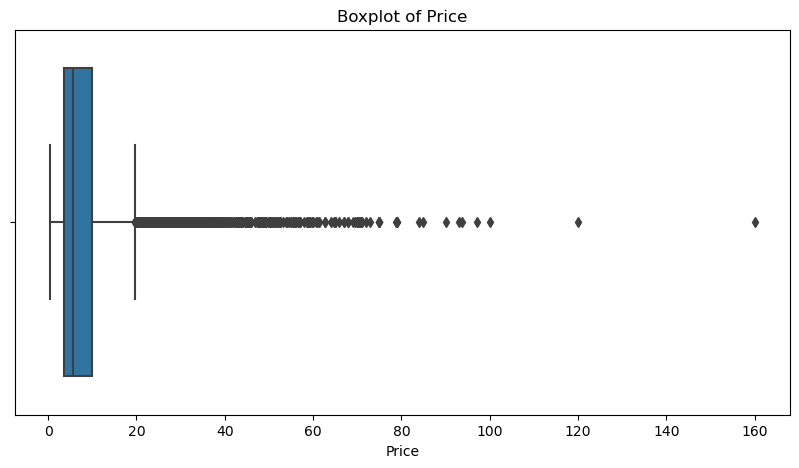

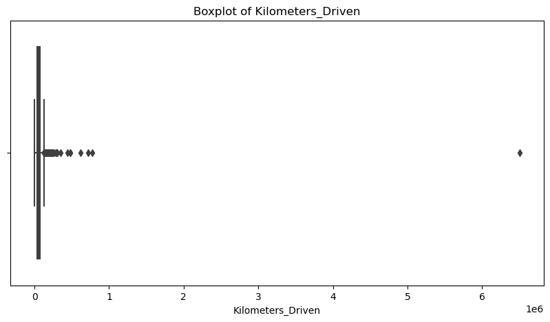

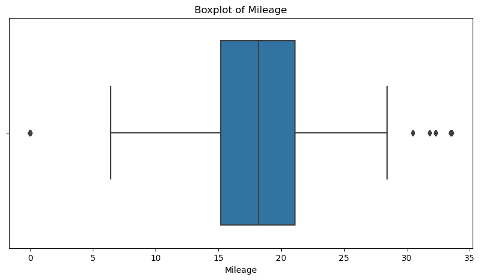

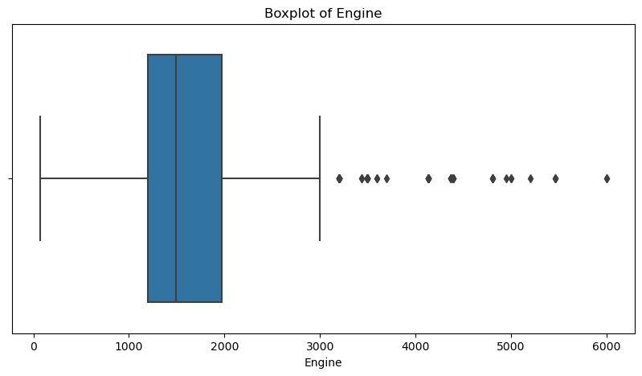

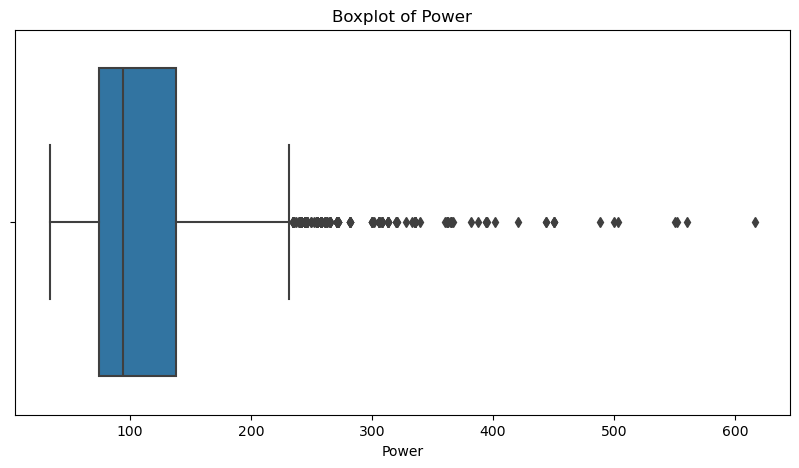

```python
# Define the columns to check for outliers
numerical_cols = ['Price', 'Kilometers_Driven', 'Mileage', 'Engine', 'Power']

# Loop through each column and create boxplots
for col in numerical_cols:
    plt.figure(figsize=(10, 5))
    sns.boxplot(x=used_cars_data[col])
    plt.title(f'Boxplot of {col}')
    plt.show()
```

### Observations from Boxplots

1. **Price Column**:
   - The boxplot shows a significant number of outliers in the "Price" column, with several data points far beyond the upper whisker, indicating high-priced cars.
   - **Comment**: These outliers could represent luxury or high-end vehicles that might skew our model. Depending on the objective, we may consider either capping extreme values or removing these outliers if they are not typical for the broader dataset.
2. **Kilometers_Driven Column**:
   - There is one extreme outlier with a value around 6.5 million kilometers, far exceeding the rest of the data points.
   - **Comment**: This outlier seems unrealistic for a used car, as most cars do not accumulate this much mileage. I Consider removing or capping this value to a more reasonable maximum.
3. **Mileage Column**:
   - A few outliers can be observed at the lower and higher ends of the mileage range. The bulk of the data is between 15 and 25 km/l, which seems reasonable.
   - **Comment**: The outliers could indicate cars with exceptionally low or high fuel efficiency. These may still be valid data points (e.g., electric cars), but we should verify them and decide whether to keep or cap these values.
4. **Engine Column**:
   - Several outliers can be seen in the upper range of the "Engine" column, especially above 3,000 cc. The bulk of the data lies below this point, suggesting these could be high-performance or specialized vehicles.
   - **Comment**: High engine capacities may be valid for certain vehicle types (e.g., trucks, SUVs), but they could skew the overall analysis. we can either retain these values if they are meaningful to the analysis or treat them as outliers based on the broader objectives of your model.
5. **Power Column**:
   - There are numerous outliers in the "Power" column, with values exceeding 400 bhp, and a few reaching up to 600 bhp.
   - **Comment**: These high-power cars likely represent sports or luxury vehicles. If the goal of the analysis is to predict prices for more common car types, we may want to remove or cap these outliers. Alternatively, we can keep them if luxury cars are relevant to the model.

#### Conclusions and Next Steps

**Outlier Treatment**: Given the presence of many outliers in key columns like "Price", "Kilometers_Driven", and "Power", we should decide on an outlier-handling strategy:

- **Capping**: For some features like "Kilometers_Driven" or "Price", capping the values to a reasonable maximum may help mitigate their impact on your model.
- **Removal**: we may choose to remove extreme outliers, especially if they represent unrealistic values or cars that are too different from the majority.
- **Domain Knowledge**: Verifying whether some of the outliers are valid (e.g., luxury or high-performance cars). If they are valid, we might keep them, but treat them carefully during model training (e.g., using robust algorithms that handle outliers well).
5. **Categorical Variables**

   For variables like "Fuel_Type", "Transmission", and "Owner_Type", it's important to understand their distribution:

```python
# Check unique values for categorical variables
print(used_cars_data['Fuel_Type'].value_counts())
print(used_cars_data['Transmission'].value_counts())
print(used_cars_data['Owner_Type'].value_counts())
```

```
Fuel_Type
Diesel      3852
Petrol      3325
CNG           62
LPG           12
Electric       2
Name: count, dtype: int64
Transmission
Manual       5204
Automatic    2049
Name: count, dtype: int64
Owner_Type
First             5952
Second            1152
Third              137
Fourth & Above      12
Name: count, dtype: int64
```

### Observations for Categorical Variables

1. **Fuel_Type**:
   - The dataset contains five types of fuel:
     - Diesel: 3,852 cars (53% of the dataset)
     - Petrol: 3,325 cars (46% of the dataset)
     - CNG: 62 cars (less than 1%)
     - LPG: 12 cars (less than 1%)
     - Electric: 2 cars (very rare, less than 1%)
   - **Comment**: The dataset is predominantly composed of diesel and petrol cars. The number of CNG, LPG, and electric cars is very small, and these categories might need special handling. we could consider merging some of the smaller categories (like LPG and Electric) or leaving them as-is but keeping their rarity in mind for modeling.
2. **Transmission**:
   - Manual: 5,204 cars (72% of the dataset)
   - Automatic: 2,049 cars (28% of the dataset)
   - **Comment**: The dataset has a majority of manual transmission cars. Since the split is reasonable, both categories can be kept for analysis, though it might be interesting to investigate whether transmission type significantly impacts car price.
3. **Owner_Type**:
   - First Owner: 5,952 cars (82% of the dataset)
   - Second Owner: 1,152 cars (16%)
   - Third Owner: 137 cars (2%)
   - Fourth & Above: 12 cars (very rare)
   - **Comment**: The vast majority of cars are first-owner vehicles, with a smaller but significant number of second-owner cars. Cars with more than two previous owners are rare, and the "Fourth & Above" category might need special consideration in modeling since it represents a small number of cases.

#### Conclusions

**Imbalanced Categories**: Categories like "Fuel_Type" (CNG, LPG, Electric) and "Owner_Type" (Third, Fourth & Above) are rare. may want to consider:

- **Grouping smaller categories**: For example, grouping CNG, LPG, and Electric into a single "Other" category, or leaving them as-is but recognizing their small sample size.
- **Handling rare categories in modeling**: Some algorithms may be sensitive to imbalanced classes, so consider techniques like oversampling, SMOTE, or treating them as separate groups.

**Important Features**:

- Transmission and Owner_Type are likely to be important features in predicting car prices. For example, automatic cars may have different price distributions than manual cars, and first-owner cars might generally be priced higher than those with multiple owners.

#### Next Steps

1. Investigate the impact of these categorical variables on car price through visualizations (e.g., boxplots or bar charts).
2. Encode these variables for modeling using techniques like one-hot encoding or label encoding, depending on the algorithms that is planned to use.
6. **Data Type Conversions**

   Ensure that the columns are of appropriate data types. For example, "Year" should be converted to integers if necessary, and categorical variables should be labeled properly for encoding:

```python
# Convert 'Year' to a numeric data type
used_cars_data['Year'] = pd.to_numeric(used_cars_data['Year'], errors='coerce')

# Convert categorical columns to category dtype
used_cars_data['Fuel_Type'] = used_cars_data['Fuel_Type'].astype('category')
used_cars_data['Transmission'] = used_cars_data['Transmission'].astype('category')
used_cars_data['Owner_Type'] = used_cars_data['Owner_Type'].astype('category')
```

## **Exploratory Data Analysis**

- EDA is an important part of any project involving data.
- It is important to investigate and understand the data better before building a model with it.
- A few questions have been mentioned below which will help you approach the analysis in the right manner and generate insights from the data.
- A thorough analysis of the data, in addition to the questions mentioned below, should be done.

**Questions:**

1. What is the summary statistics of the data? Explore summary statistics for numerical variables and the categorical variables
2. Find out number of unique observations in each category of categorical columns? Write your findings/observations/insights
3. Check the extreme values in different columns of the given data and write down the observtions? Remove the data where the values are un-realistic

### 1. Summary Statistics for Numerical and Categorical Variables

#### For Numerical Variables:

To get the summary statistics (mean, median, standard deviation, etc.) for numerical columns:

```python
# Summary statistics for numerical variables
numerical_summary = used_cars_data.describe()
print(numerical_summary)
```

```
             S.No.         Year  Kilometers_Driven      Mileage       Engine  \
count  7253.000000  7253.000000       7.253000e+03  7251.000000  7207.000000
mean   3626.000000  2013.365366       5.869906e+04    18.141580  1616.573470
std    2093.905084     3.254421       8.442772e+04     4.562197   595.285137
min       0.000000  1996.000000       1.710000e+02     0.000000    72.000000
25%    1813.000000  2011.000000       3.400000e+04    15.170000  1198.000000
50%    3626.000000  2014.000000       5.341600e+04    18.160000  1493.000000
75%    5439.000000  2016.000000       7.300000e+04    21.100000  1968.000000
max    7252.000000  2019.000000       6.500000e+06    33.540000  5998.000000

             Power        Seats    New_price        Price
count  7078.000000  7200.000000  1006.000000  6019.000000
mean    112.765214     5.280417    22.779692     9.479468
std      53.493553     0.809277    27.759344    11.187917
min      34.200000     2.000000     3.910000     0.440000
25%      75.000000     5.000000     7.885000     3.500000
50%      94.000000     5.000000    11.570000     5.640000
75%     138.100000     5.000000    26.042500     9.950000
max     616.000000    10.000000   375.000000   160.000000
```

#### For Categorical Variables:

We can get the summary of unique values in each categorical column:

```python
# Summary statistics for categorical variables
categorical_cols = ['Fuel_Type', 'Transmission', 'Owner_Type', 'Location']
for col in categorical_cols:
    print(f'{col} Summary:')
    print(used_cars_data[col].value_counts())
    print("\n")
```

```
Fuel_Type Summary:
Fuel_Type
Diesel      3852
Petrol      3325
CNG           62
LPG           12
Electric       2
Name: count, dtype: int64


Transmission Summary:
Transmission
Manual       5204
Automatic    2049
Name: count, dtype: int64


Owner_Type Summary:
Owner_Type
First             5952
Second            1152
Third              137
Fourth & Above      12
Name: count, dtype: int64


Location Summary:
Location
Mumbai        949
Hyderabad     876
Coimbatore    772
Kochi         772
Pune          765
Delhi         660
Kolkata       654
Chennai       591
Jaipur        499
Bangalore     440
Ahmedabad     275
Name: count, dtype: int64
```

### Summary Statistics and Insights

#### 1. Numerical Variables:

Here are the summary statistics for the numerical variables:

- **Year**: The cars in the dataset were manufactured between 1996 and 2019, with a median year of 2014. This indicates that the dataset mostly includes fairly recent cars.
- **Kilometers_Driven**: The range is very wide, from 171 km to over 6.5 million km. The median is around 53,416 km, which is a typical mileage for a used car, but the high max value suggests some potential outliers.
- **Mileage**: Mileage varies from 0 to 33.54 km/l, with a median value of 18.16 km/l. This seems reasonable, but a value of 0 could be problematic and should be investigated.
- **Engine**: The engine size ranges from 72 cc to 5,998 cc, with a median value of 1,493 cc. Larger engine sizes likely correspond to high-performance or luxury cars.
- **Power**: The power ranges from 34.2 bhp to 616 bhp, with a median of 94 bhp. High-power cars (over 300 bhp) could be outliers or luxury vehicles.
- **Seats**: Most cars have 5 seats, but there are some cars with as few as 2 or as many as 10 seats. These extremes likely correspond to sports cars and commercial vehicles, respectively.
- **New_Price**: New price data is limited, with only 1,006 non-null values. The range is from ₹3.91 lakh to ₹375 lakh, which includes both budget and luxury cars.
- **Price**: The resale price ranges from ₹44,000 to ₹1.6 crore, with a median value of ₹5.64 lakh. The high variability in prices suggests a diverse range of cars, including both budget and luxury models.

#### 2. Categorical Variables:

- **Fuel_Type**:
  - Diesel (3,852) and Petrol (3,325) are the dominant fuel types, covering almost the entire dataset.
  - CNG (62), LPG (12), and Electric (2) cars are very rare and may need special handling during analysis.
- **Transmission**:
  - Manual (5,204) transmission cars dominate the dataset (72%), while Automatic (2,049) cars represent 28%. This could indicate that automatic cars are more valuable or less common in certain markets.
- **Owner_Type**:
  - First owners (5,952) are the majority, indicating that most cars have not changed hands often.
  - Second owners (1,152) make up a smaller portion, while Third (137) and Fourth & Above (12) owners are rare. The number of owners could impact price, with more owners potentially lowering resale value.
- **Location**:
  - The dataset includes cars from various cities, with Mumbai (949), Hyderabad (876), and Coimbatore (772) having the highest number of listings.
  - Smaller cities like Ahmedabad (275) have fewer cars listed. Prices may vary significantly based on location, reflecting different demand levels in each city.

#### Observations/Insights:

**Numerical Variables**:

- Kilometers_Driven has extreme values that likely represent outliers and should be handled appropriately (capping or removal).
- The Mileage column includes values of 0, which should be investigated or imputed as they are likely missing or incorrect data.
- Price and Power have large ranges, suggesting a diverse set of vehicles, from budget to high-end luxury cars.

**Categorical Variables**:

#### Next Steps:

1. **Handle Missing Data**: Investigate and possibly impute missing values in the Mileage and New_Price columns.
2. **Outlier Detection and Removal**: Address the outliers in Kilometers_Driven, Price, Power, and other numerical variables to improve model performance.
3. **Location and Owner Analysis**: Perform further analysis to understand how location and owner history impact resale price.

### 2. Unique Observations in Categorical Columns

For each categorical variable, find out the number of unique observations and write your findings:

```python
# Unique observations in categorical columns
for col in categorical_cols:
    print(f'{col}: {used_cars_data[col].nunique()} unique values')
```

```
Fuel_Type: 5 unique values
Transmission: 2 unique values
Owner_Type: 4 unique values
Location: 11 unique values
```

#### Fuel_Type:

- **Unique Values**: 5 (Diesel, Petrol, CNG, LPG, Electric)
- **Findings**: Diesel and Petrol dominate, while CNG, LPG, and Electric are rare categories. This distribution suggests that Diesel and Petrol cars will be more predictive for price estimation.
- **Recommendation**: For modeling purposes, consider grouping CNG, LPG, and Electric into an "Other" category due to their rarity, unless we have enough data for them to impact pricing significantly.

#### Transmission:

- **Unique Values**: 2 (Manual, Automatic)
- **Findings**: A binary distribution of transmission type provides a straightforward comparison. Manual cars are the majority, but Automatic transmission cars may hold higher value in certain locations or markets.
- **Recommendation**: Retain both categories as-is, as they may play a role in the resale value. We could also investigate if automatic transmissions affect prices more in urban areas.

#### Owner_Type:

- **Unique Values**: 4 (First, Second, Third, Fourth & Above)
- **Findings**: The distribution shows a strong skew toward first-owner cars, with very few cars having three or more previous owners. Generally, cars with fewer owners are likely valued higher.
- **Recommendation**: Since the number of owners can influence price (with more owners potentially lowering the value), keep all categories separate. However, during modeling, we may consider combining "Third" and "Fourth & Above" if they don't contribute much variance individually.

#### Location:

- **Unique Values**: 11
- **Findings**: The dataset includes cars from 11 cities, with Mumbai, Hyderabad, and Coimbatore having the most listings. Prices may vary by location due to regional demand, cost of living, and market preferences.
- **Recommendation**: Retain all locations as they provide a geographical dimension that could impact price. Further analysis could reveal how each location influences car prices, possibly requiring separate models or adjusting prices based on regional factors.

### 3. Checking Extreme Values in Different Columns

We have already done some outlier detection using boxplots, so we can expand that by checking specific extreme values.

```python
# Check for extreme values in Price, Kilometers_Driven, Mileage, Engine, Power
extreme_values = used_cars_data[(used_cars_data['Price'] > 100) |
                                (used_cars_data['Kilometers_Driven'] > 500000) |
                                (used_cars_data['Mileage'] < 5) |
                                (used_cars_data['Engine'] > 4000) |
                                (used_cars_data['Power'] > 500)]
print(extreme_values)
```

```
      S.No.                                      Name    Location  Year  \
14       14            Land Rover Freelander 2 TD4 SE        Pune  2012
67       67  Mercedes-Benz C-Class Progressive C 220d  Coimbatore  2019
70       70           Porsche Cayenne 2009-2014 Turbo      Mumbai  2008
79       79                    Hyundai Santro Xing XL   Hyderabad  2005
152     152     Mercedes-Benz S Class 2005 2013 S 500     Kolkata  2010
...     ...                                       ...         ...   ...
6697   6697                    Hyundai Santro Xing XL      Jaipur  2007
6857   6857            Land Rover Freelander 2 TD4 SE      Mumbai  2011
6957   6957                    Honda Jazz 2020 Petrol       Kochi  2019
7057   7057                   BMW 6 Series 650i Coupe       Delhi  2009
7226   7226                    Hyundai Santro Xing GL   Ahmedabad  2014

      Kilometers_Driven Fuel_Type Transmission Owner_Type  Mileage  Engine  \
14                85000    Diesel    Automatic     Second     0.00  2179.0
```

[output cut: 25 more lines]

## **Univariate Analysis**

**Questions:**

1. Do univariate analysis for numerical and categorical variables?
2. Check the distribution of the different variables? is the distributions skewed?
3. Do we need to do log_transformation, if so for what variables we need to do?
4. Perfoem the log_transformation(if needed) and write down your observations?

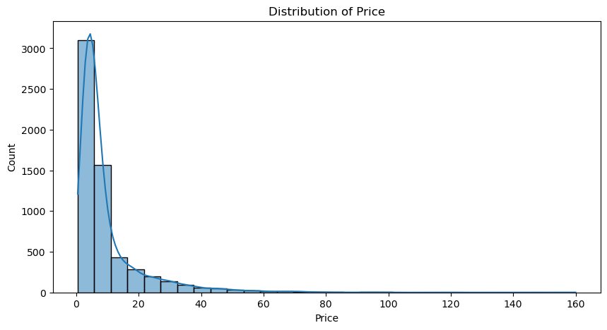

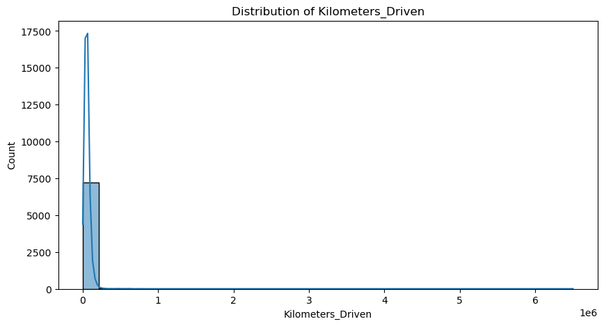

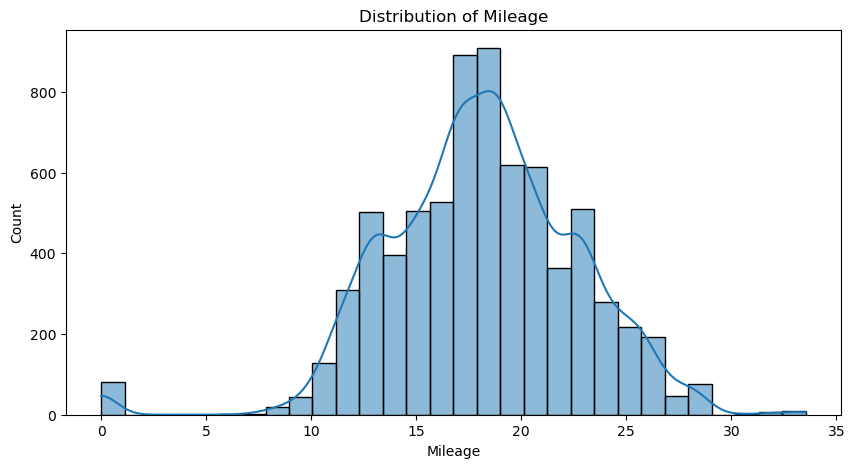

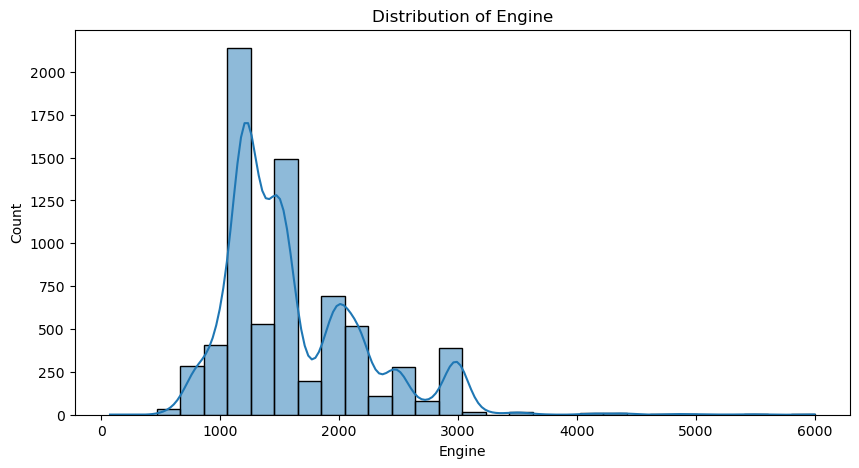

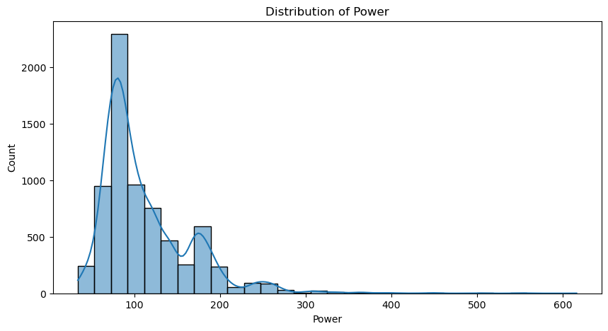

```python
# List of numerical columns to analyze
numerical_cols = ['Price', 'Kilometers_Driven', 'Mileage', 'Engine', 'Power']

# Plot histograms for each numerical variable
import matplotlib.pyplot as plt
import seaborn as sns

for col in numerical_cols:
    plt.figure(figsize=(10, 5))
    sns.histplot(used_cars_data[col], kde=True, bins=30)
    plt.title(f'Distribution of {col}')
    plt.show()
```

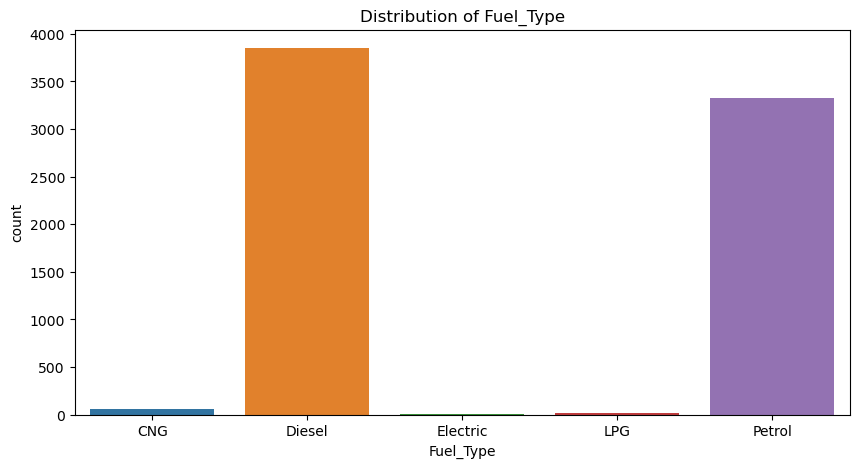

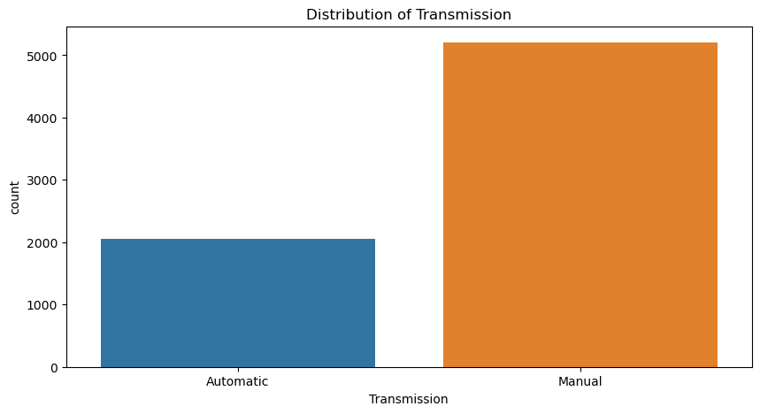

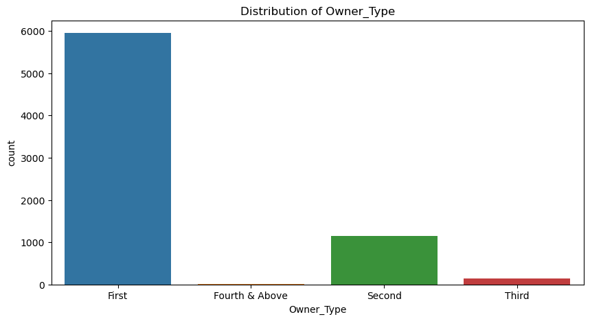

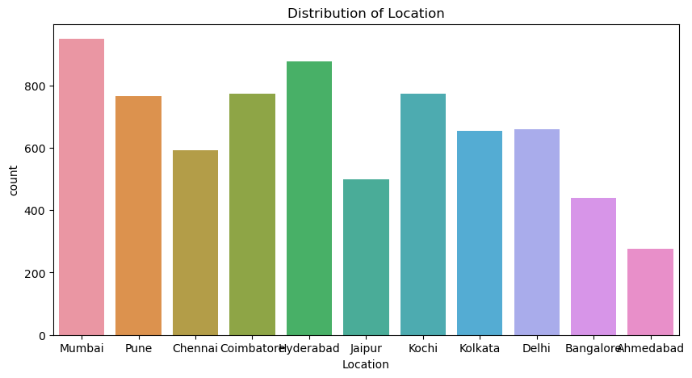

```python
# Categorical variables to analyze
categorical_cols = ['Fuel_Type', 'Transmission', 'Owner_Type', 'Location']

# Plot bar plots for each categorical variable
for col in categorical_cols:
    plt.figure(figsize=(10, 5))
    sns.countplot(x=used_cars_data[col])
    plt.title(f'Distribution of {col}')
    plt.show()
```

### Observations and Insights from Univariate Analysis

#### Numerical Variables:

- **Price**:
  - The distribution is heavily right-skewed, with a high concentration of cars priced under ₹20 lakh. A small number of luxury or high-value cars drive the long tail.
  - **Recommendation**: Apply a log transformation to Price to reduce skewness and make it more suitable for modeling.
- **Kilometers_Driven**:
  - The distribution is extremely right-skewed, with most cars having lower mileage but a few high-mileage outliers extending to 6.5 million km.
  - **Recommendation**: Cap the upper extreme values and consider applying a log transformation to normalize this feature.
- **Mileage**:
  - The distribution of Mileage is approximately normal, with a peak around 18-20 km/l. However, there are a few outliers on both the lower and upper ends.
  - **Recommendation**: Investigate the outliers, especially values of 0 km/l, which might represent missing or incorrect data.
- **Engine**:
  - The Engine distribution shows several peaks, likely due to the presence of various engine classes (small, medium, and large engines).
  - **Recommendation**: Retain this distribution as it is, but consider investigating and categorizing engine types if it benefits model performance.
- **Power**:
  - The distribution of Power is right-skewed, with most cars under 200 bhp. The long tail represents high-performance vehicles.
  - **Recommendation**: A log transformation might help normalize the data and handle the skewness.

#### Categorical Variables:

- **Fuel_Type**:
  - Diesel and Petrol are the dominant categories, while CNG, LPG, and Electric are rare.
  - **Recommendation**: Considering grouping CNG, LPG, and Electric into an "Other" category due to their low representation.
- **Transmission**:
  - Manual transmission is significantly more common than automatic, suggesting that manual cars may have a larger impact on model predictions.
  - **Recommendation**: Retain both categories, as Transmission might influence car prices differently depending on location or type.
- **Owner_Type**:
  - Most cars are first-owner vehicles, with fewer cars owned by second, third, or fourth owners.
  - **Recommendation**: Since the number of previous owners can impact price, retain all categories as-is. Consider grouping "Third" and "Fourth & Above" if they show similar price trends.
- **Location**:
  - The dataset covers 11 cities, with higher listings in cities like Mumbai, Hyderabad, and Coimbatore.
  - **Recommendation**: Retain all locations, as location-specific trends can significantly impact car prices. We might also investigate the possibility of region-based grouping (e.g., metro vs. non-metro).

```python
# Check for skewness in numerical variables
print(used_cars_data[numerical_cols].skew())
```

```
Price                 3.335232
Kilometers_Driven    61.582575
Mileage              -0.438321
Engine                1.412413
Power                 1.961178
dtype: float64
```

#### Based on the Skewness Values, Here’s an Interpretation of Each Variable and Recommended Transformations:

- **Price**: Skewness of 3.335 indicates a strong positive skew.
  - **Recommendation**: Apply a log transformation to reduce skewness and make the distribution more normal, which can improve model performance.
- **Kilometers_Driven**: Extremely high skewness of 61.582 indicates significant right skew.
  - **Recommendation**: Cap extreme values to a reasonable maximum (e.g., the 99th percentile) and apply a log transformation. This will help in reducing the impact of outliers.
- **Mileage**: Skewness of -0.438 indicates mild left skew, which is relatively normal.
  - **Recommendation**: No transformation is necessary, as the skewness is mild and shouldn’t negatively impact the model.
- **Engine**: Skewness of 1.412 suggests moderate right skew.
  - **Recommendation**: Consider a log transformation if this feature is important for modeling. This can help in reducing skewness and stabilizing variance.
- **Power**: Skewness of 1.961 shows a strong right skew.
  - **Recommendation**: Apply a log transformation to reduce skewness and improve the distribution, especially since power may correlate with car price.

## Adjusments

### Remove Unrealistic Values

First, let’s identify and remove any unrealistic values. Based on the univariate analysis, these could include:

- **Price**: Remove values that are too high (e.g., above 100 lakh).
- **Kilometers_Driven**: Cap extremely high values at a reasonable maximum.
- **Mileage**: Investigate and handle values equal to 0 (likely incorrect or missing).

```python
# Removing unrealistic values for Price
# Defining thresholds for elimination of extreme values
# Check for extreme values in Price, Kilometers_Driven, Mileage, Engine, Power
extreme_values = used_cars_data[(used_cars_data['Price'] > 100) |
                                (used_cars_data['Kilometers_Driven'] > 500000) |
                                (used_cars_data['Mileage'] < 5) |
                                (used_cars_data['Engine'] > 4000) |
                                (used_cars_data['Power'] > 500)]

# Drop the extreme values from the dataset
used_cars_data = used_cars_data.drop(extreme_values.index)

# Handling 0 values in Mileage (replace with median or drop)
used_cars_data.replace({'Mileage': {0: used_cars_data['Mileage'].median()}}, inplace=True)
```

```python
print(used_cars_data.info())
```

```
<class 'pandas.core.frame.DataFrame'>
Index: 7137 entries, 0 to 7252
Data columns (total 14 columns):
 #   Column             Non-Null Count  Dtype
---  ------             --------------  -----
 0   S.No.              7137 non-null   int64
 1   Name               7137 non-null   object
 2   Location           7137 non-null   object
 3   Year               7137 non-null   int64
 4   Kilometers_Driven  7137 non-null   int64
 5   Fuel_Type          7137 non-null   category
 6   Transmission       7137 non-null   category
 7   Owner_Type         7137 non-null   category
 8   Mileage            7135 non-null   float64
 9   Engine             7103 non-null   float64
 10  Power              7007 non-null   float64
 11  Seats              7098 non-null   float64
 12  New_price          999 non-null    float64
 13  Price              5918 non-null   float64
dtypes: category(3), float64(6), int64(3), object(2)
memory usage: 690.5+ KB
None
```

### Apply Log Transformation for Skewed Variables

```python
# Log transform for skewed variables
used_cars_data['Log_Price'] = np.log1p(used_cars_data['Price'])  # For Price
used_cars_data['Log_Kilometers_Driven'] = np.log1p(used_cars_data['Kilometers_Driven'])  # For Kilometers_Driven
used_cars_data['Log_Power'] = np.log1p(used_cars_data['Power'])  # For Power
```

### Cap Extreme Values for Kilometers_Driven

Cap Kilometers_Driven at the 99th percentile to remove extreme values, then apply a log transformation.

```python
# Capping extreme values at the 99th percentile
km_cap = used_cars_data['Kilometers_Driven'].quantile(0.99)
used_cars_data['Kilometers_Driven'] = np.where(used_cars_data['Kilometers_Driven'] > km_cap, km_cap, used_cars_data['Kilometers_Driven'])

# Apply log transformation after capping
used_cars_data['Log_Kilometers_Driven'] = np.log1p(used_cars_data['Kilometers_Driven'])
```

### Apply Log Transformation for Power

Since Power is strongly skewed, apply the log transformation.

```python
# Log transform Power
used_cars_data['Log_Power'] = np.log1p(used_cars_data['Power'])
```

### Decide on Engine Transformation

Engine has moderate skewness (1.412), so it may benefit from log transformation. Applying the transformation depends on whether the feature has outliers or if the range is large enough to need normalization. Since we observed that Engine has a diverse range, we can apply the log transformation to reduce skewness.

```python
# Log transform Engine
used_cars_data['Log_Engine'] = np.log1p(used_cars_data['Engine'])
```

### Group Rare Fuel Types into "Other"

Combine rare categories in Fuel_Type (CNG, LPG, Electric) into a single "Other" category to simplify modeling.

```python
# Group rare fuel types
used_cars_data['Fuel_Type'] = used_cars_data['Fuel_Type'].replace(['CNG', 'LPG', 'Electric'], 'Other')
```

- **Unrealistic values in Price and Mileage have been handled.**
- **Log transformations have been applied to Price, Kilometers_Driven, Power, and Engine to reduce skewness.**
- **Extreme values in Kilometers_Driven have been capped.**
- **Fuel_Type has been simplified by grouping rare categories into "Other."**

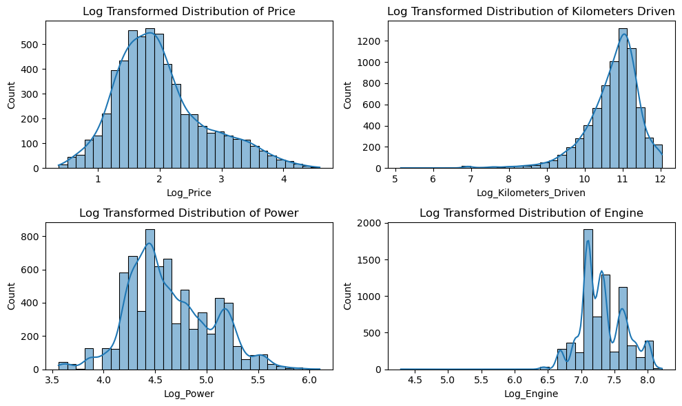

```python
# Plotting the transformed distributions
plt.figure(figsize=(10, 6))

# Transformed Price
plt.subplot(2, 2, 1)
sns.histplot(used_cars_data['Log_Price'], kde=True, bins=30)
plt.title('Log Transformed Distribution of Price')

# Transformed Kilometers_Driven
plt.subplot(2, 2, 2)
sns.histplot(used_cars_data['Log_Kilometers_Driven'], kde=True, bins=30)
plt.title('Log Transformed Distribution of Kilometers Driven')

# Transformed Power
plt.subplot(2, 2, 3)
sns.histplot(used_cars_data['Log_Power'], kde=True, bins=30)
plt.title('Log Transformed Distribution of Power')

# Transformed Engine
plt.subplot(2, 2, 4)
sns.histplot(used_cars_data['Log_Engine'], kde=True, bins=30)
plt.title('Log Transformed Distribution of Engine')

plt.tight_layout()
plt.show()
```

- **Log Transformed Distribution of Price:**

  The distribution is now closer to normal, with a more symmetrical shape. This transformation should enhance model performance by stabilizing the variance in price and reducing the impact of outliers.
- **Log Transformed Distribution of Kilometers Driven:**

  The transformation has reduced the extreme right skew. Most data points now fall within a more normalized range, making this variable more suitable for correlation and regression analysis.
- **Log Transformed Distribution of Power:**

  The distribution of power is now more balanced, though it retains some multimodality, possibly due to variations in engine types (e.g., economy, performance, and luxury cars). The transformation has made the data less skewed and easier to interpret.
- **Log Transformed Distribution of Engine:**

  The transformation has helped reduce skewness, though the distribution is still somewhat multi-peaked. This may reflect different types or categories of engines. The transformation improves consistency in the data, but the multimodal nature suggests there may be distinct segments within this feature.

## **Bivariate Analysis**

**Questions:**

1. Plot a scatter plot for the log transformed values(if log_transformation done in previous steps)?
2. What can we infer form the correlation heatmap? Is there correlation between the dependent and independent variables?
3. Plot a box plot for target variable and categorical variable 'Location' and write your observations?
- **Correlation Heatmap (Original and Transformed Numerical Variables):**

  Show correlations between Price (original and log-transformed) and numerical features (both original and transformed).
- **Scatter Plots:**

  Visualize relationships between Price and other continuous variables (original and transformed versions).
- **Box Plots for Categorical Variables:**

  Explore relationships between Price (original and log-transformed) and categorical variables to see if different categories have a clear impact on price.

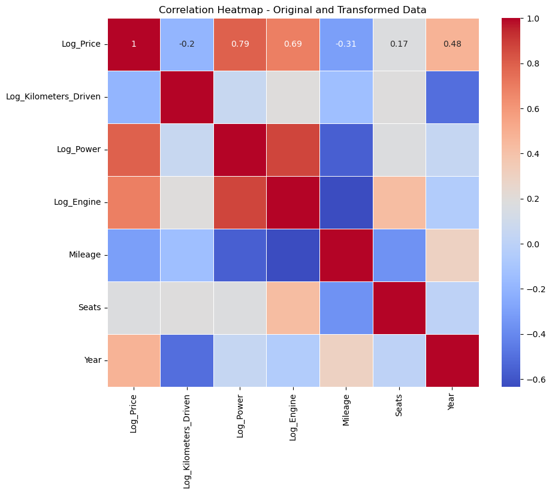

```python
# Including both original and log-transformed variables in correlation matrix
corr_data_all = used_cars_data[['Log_Price','Log_Kilometers_Driven','Log_Power','Log_Engine','Mileage','Seats','Year']]
correlation_matrix_all = corr_data_all.corr()

# Plotting the heatmap
plt.figure(figsize=(10, 8))
sns.heatmap(correlation_matrix_all, annot=True, cmap='coolwarm', linewidths=0.5)
plt.title('Correlation Heatmap - Original and Transformed Data')
plt.show()
```

### Scatter Plots for Log_Price with Key Numerical Variables

1. **Log_Price vs Log_Power**
2. **Log_Price vs Log_Engine**
3. **Log_Price vs Year**
4. **Log_Price vs Mileage**
5. **Log_Price vs Log_Kilometers_Driven**

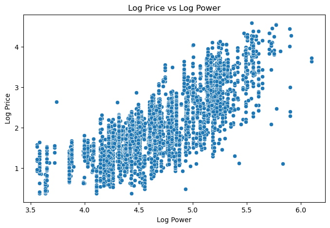

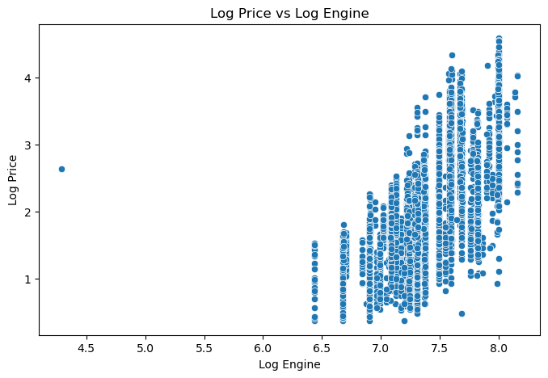

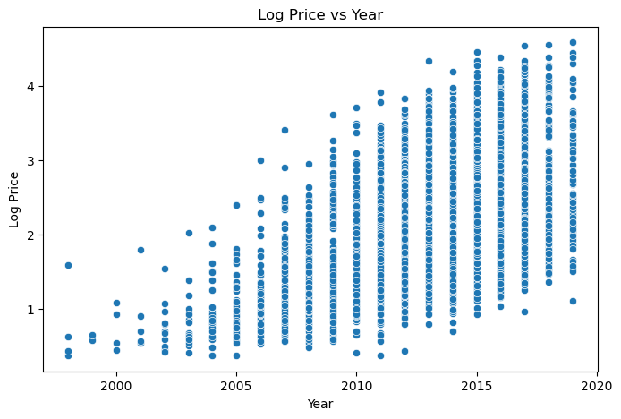

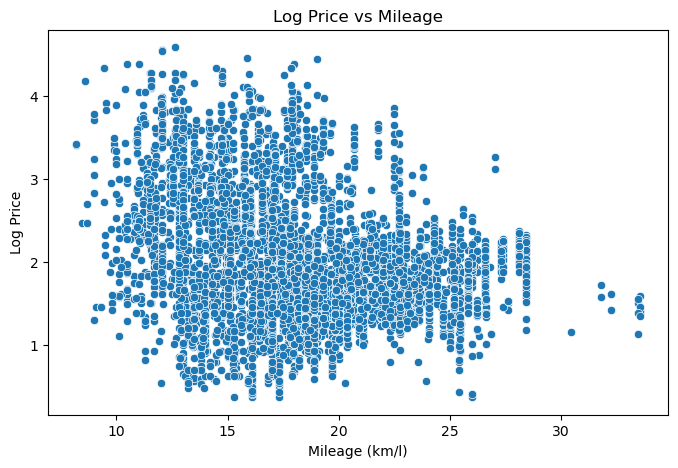

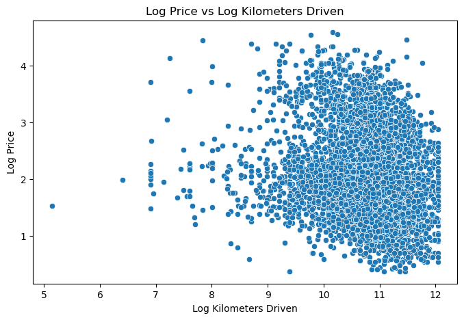

```python
# Scatter plot for Log_Price vs Log_Power
plt.figure(figsize=(8, 5))
sns.scatterplot(x=used_cars_data['Log_Power'], y=used_cars_data['Log_Price'])
plt.title('Log Price vs Log Power')
plt.xlabel('Log Power')
plt.ylabel('Log Price')
plt.show()

# Scatter plot for Log_Price vs Log_Engine
plt.figure(figsize=(8, 5))
sns.scatterplot(x=used_cars_data['Log_Engine'], y=used_cars_data['Log_Price'])
plt.title('Log Price vs Log Engine')
plt.xlabel('Log Engine')
plt.ylabel('Log Price')
plt.show()

# Scatter plot for Log_Price vs Year
plt.figure(figsize=(8, 5))
sns.scatterplot(x=used_cars_data['Year'], y=used_cars_data['Log_Price'])
plt.title('Log Price vs Year')
plt.xlabel('Year')
plt.ylabel('Log Price')
plt.show()

# Scatter plot for Log_Price vs Mileage
plt.figure(figsize=(8, 5))
sns.scatterplot(x=used_cars_data['Mileage'], y=used_cars_data['Log_Price'])
plt.title('Log Price vs Mileage')
plt.xlabel('Mileage (km/l)')
plt.ylabel('Log Price')
plt.show()

# Scatter plot for Log_Price vs Log_Kilometers_Driven
plt.figure(figsize=(8, 5))
sns.scatterplot(x=used_cars_data['Log_Kilometers_Driven'], y=used_cars_data['Log_Price'])
plt.title('Log Price vs Log Kilometers Driven')
plt.xlabel('Log Kilometers Driven')
plt.ylabel('Log Price')
plt.show()
```

### Box Plots for Log_Price with Categorical Variables

1. **Log_Price vs Fuel_Type**
2. **Log_Price vs Transmission**
3. **Log_Price vs Owner_Type**
4. **Log_Price vs Location**

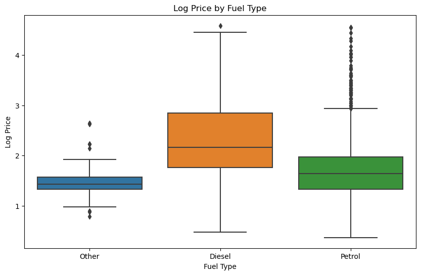

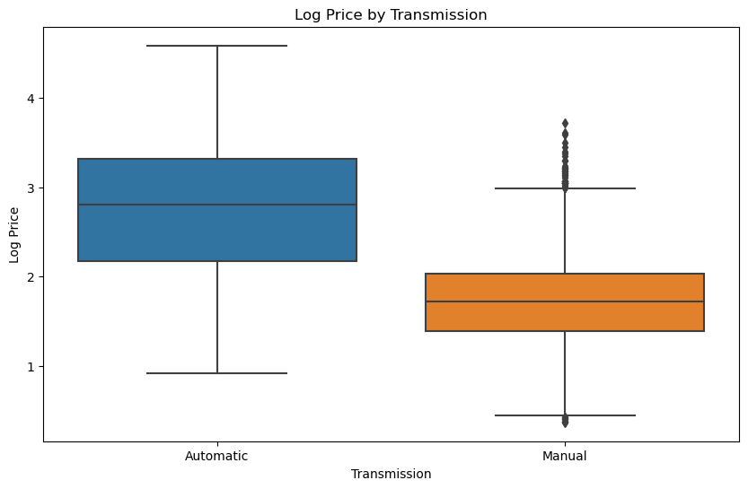

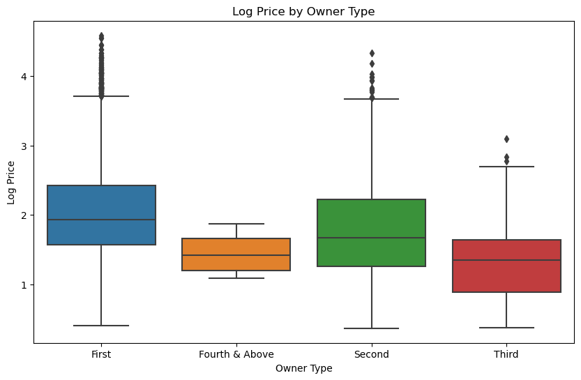

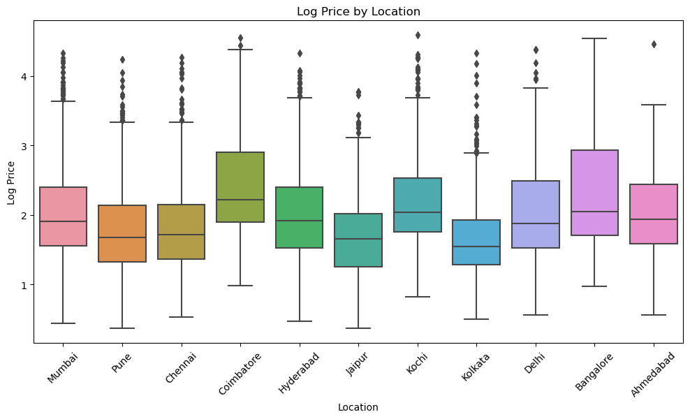

```python
# Box plot for Log_Price by Fuel_Type
plt.figure(figsize=(10, 6))
sns.boxplot(x=used_cars_data['Fuel_Type'], y=used_cars_data['Log_Price'])
plt.title('Log Price by Fuel Type')
plt.xlabel('Fuel Type')
plt.ylabel('Log Price')
plt.show()

# Box plot for Log_Price by Transmission
plt.figure(figsize=(10, 6))
sns.boxplot(x=used_cars_data['Transmission'], y=used_cars_data['Log_Price'])
plt.title('Log Price by Transmission')
plt.xlabel('Transmission')
plt.ylabel('Log Price')
plt.show()

# Box plot for Log_Price by Owner_Type
plt.figure(figsize=(10, 6))
sns.boxplot(x=used_cars_data['Owner_Type'], y=used_cars_data['Log_Price'])
plt.title('Log Price by Owner Type')
plt.xlabel('Owner Type')
plt.ylabel('Log Price')
plt.show()

# Box plot for Log_Price by Location
plt.figure(figsize=(12, 6))
sns.boxplot(x=used_cars_data['Location'], y=used_cars_data['Log_Price'])
plt.xticks(rotation=45)
plt.title('Log Price by Location')
plt.xlabel('Location')
plt.ylabel('Log Price')
plt.show()
```

### Log Price vs Log Power:

- There is a positive correlation between car price and power, as expected. Higher power generally corresponds to higher prices.
- The spread widens with increased power, indicating variability in pricing among high-powered cars, possibly due to other influencing factors like brand or condition.

### Log Price vs Log Engine:

- Similar to power, a positive correlation exists between engine size and price.
- This correlation is moderate but suggests that larger engines (in terms of cc) are more valuable, which is typical in luxury or performance cars.

### Log Price vs Year:

- A clear positive trend shows that newer cars are generally priced higher than older models.
- This relationship is logical due to depreciation—older cars lose value over time, while newer models hold a higher market value.

### Log Price vs Mileage:

- The relationship here appears more dispersed, with no strong trend.
- This suggests that mileage alone may not be a major factor affecting price, or that it varies greatly depending on other factors like car age, model, or brand.

### Log Price vs Log Kilometers Driven:

- There’s a slight negative correlation, indicating that cars with higher kilometers tend to have lower prices.
- This aligns with the idea that more usage (higher kilometers) generally decreases the resale value of a vehicle.

#### Log Price by Fuel Type:

- Diesel cars generally have a higher median price compared to petrol and other fuel types.
- The "Other" category (CNG, LPG, Electric) shows a lower price range, likely due to market demand and availability.

#### Log Price by Owner Type:

- First-owner cars have a higher median price compared to second or third-owner cars, which makes sense as cars with fewer owners are generally valued higher.
- Fourth & Above owners show a lower price range, likely due to perceived lower reliability and higher potential maintenance costs.

### Conclusion

These visualizations provide valuable insights:

- Power and Engine Size are positively correlated with price, suggesting they can be important predictors.
- Year and Kilometers Driven also relate to price, with newer cars and those with fewer kilometers being more valuable.
- Transmission Type and Owner Type have significant effects on pricing, with automatic and first-owner cars generally commanding higher prices.
- Location plays a role, indicating that regional market factors could influence pricing, which could be useful for location-based pricing strategies.

### Scatter Plots for Relationships Among Independent Variables

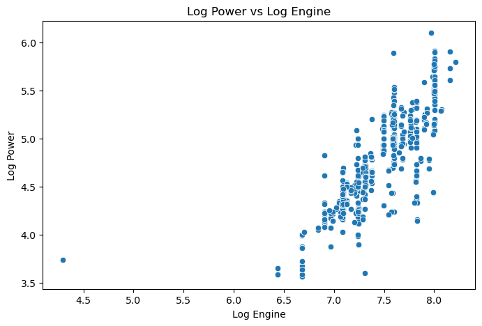

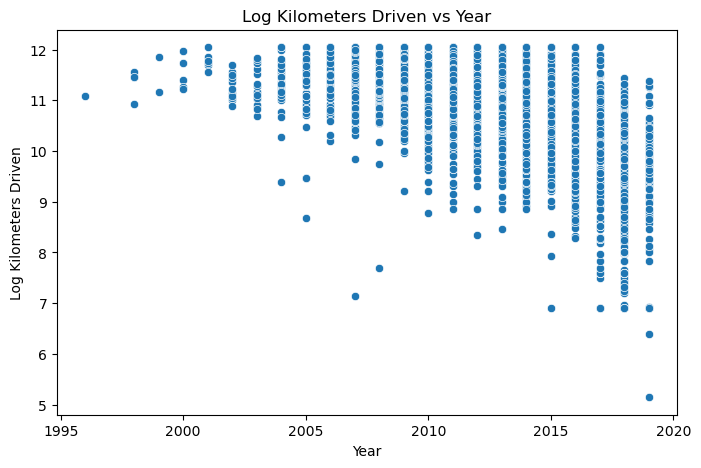

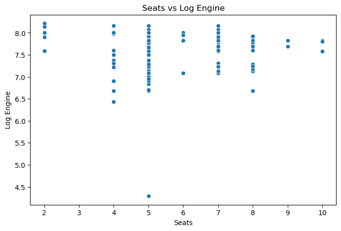

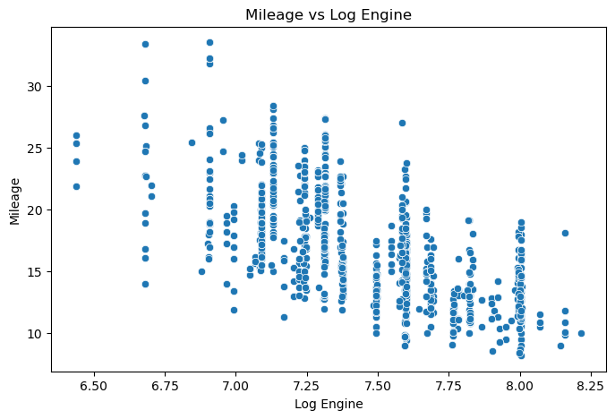

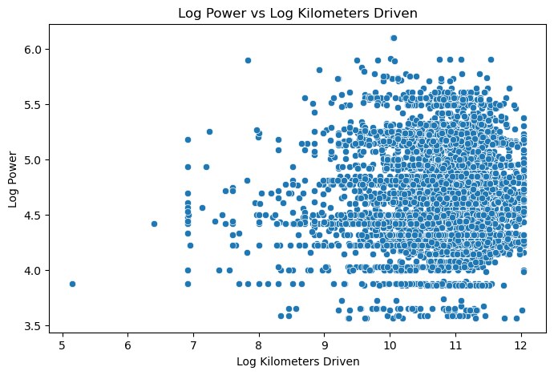

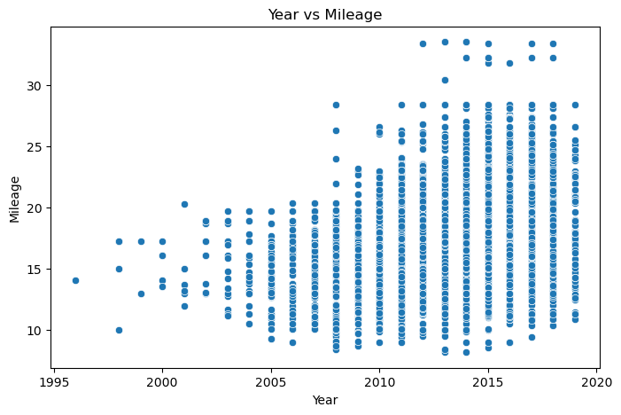

```python
# Scatter plot for Power vs Engine
plt.figure(figsize=(8, 5))
sns.scatterplot(x=used_cars_data['Log_Engine'], y=used_cars_data['Log_Power'])
plt.title('Log Power vs Log Engine')
plt.xlabel('Log Engine')
plt.ylabel('Log Power')
plt.show()

# Scatter plot for Kilometers_Driven vs Year
plt.figure(figsize=(8, 5))
sns.scatterplot(x=used_cars_data['Year'], y=used_cars_data['Log_Kilometers_Driven'])
plt.title('Log Kilometers Driven vs Year')
plt.xlabel('Year')
plt.ylabel('Log Kilometers Driven')
plt.show()

# Scatter plot for Seats vs Engine
plt.figure(figsize=(8, 5))
sns.scatterplot(x=used_cars_data['Seats'], y=used_cars_data['Log_Engine'])
plt.title('Seats vs Log Engine')
plt.xlabel('Seats')
plt.ylabel('Log Engine')
plt.show()

# Scatter plot for Mileage vs Engine
plt.figure(figsize=(8, 5))
sns.scatterplot(x=used_cars_data['Log_Engine'], y=used_cars_data['Mileage'])
plt.title('Mileage vs Log Engine')
plt.xlabel('Log Engine')
plt.ylabel('Mileage')
plt.show()

# Scatter plot for Power vs Kilometers_Driven
plt.figure(figsize=(8, 5))
sns.scatterplot(x=used_cars_data['Log_Kilometers_Driven'], y=used_cars_data['Log_Power'])
plt.title('Log Power vs Log Kilometers Driven')
plt.xlabel('Log Kilometers Driven')
plt.ylabel('Log Power')
plt.show()

# Scatter plot for Year vs Mileage
plt.figure(figsize=(8, 5))
sns.scatterplot(x=used_cars_data['Year'], y=used_cars_data['Mileage'])
plt.title('Year vs Mileage')
plt.xlabel('Year')
plt.ylabel('Mileage')
plt.show()
```